# TABLERO DESCRIPCIÓN ESTADÍSTICA

Carlos Mario Loaiza Cifuentes

## **EVA (Evaluciones Agropecuarias Municipales)**

Las evaluaciones agropecuarias municipales (EVA) son la base de información y conocimiento sobre la oferta productiva agropecuaria de los municipios del país (Colombia), una operación estratégica para la generación de estadísticas y la toma de decisiones en el sector.

La entidad encargada de realizar las EVA es La Unidad de Planificación Rural Agropecuaria (UPRA) en coordinación con otras entidades territoriales y nacionales, estas se realizan desde 1970 y se desarrollan en módulos temáticos que se recolectan anualmente o periódicamente.

### Variable DEPARTAMENTO

Se refiere al departamento de Colombia donde se realizó la toma de los datos.

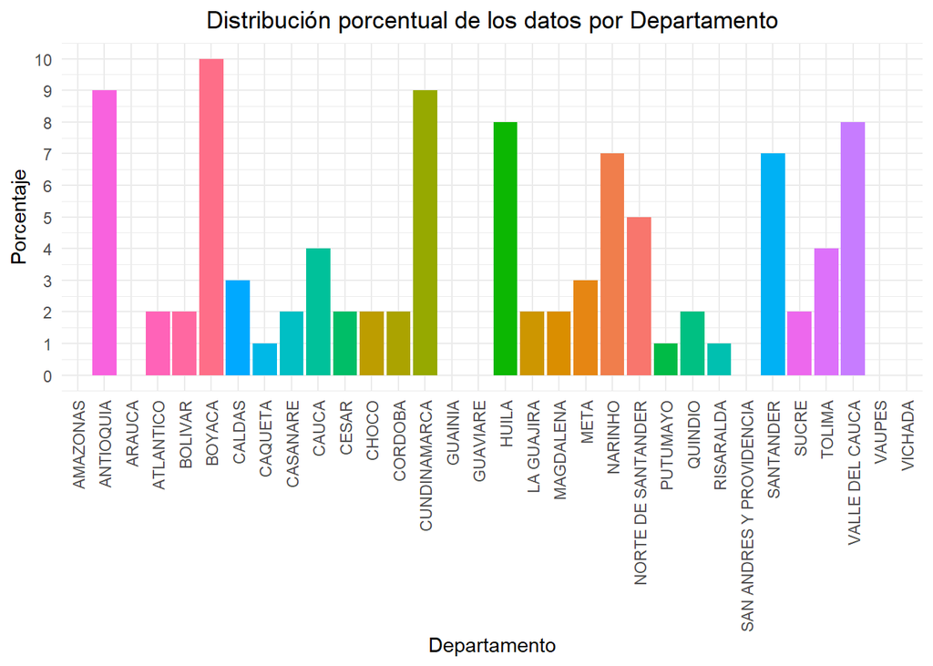

En esta gráfica se puede observar que:

[output not shown]

[figure not shown]

Mapa de colombia con sus departamentos y regiones

### Variable MUNICIPIO

Se refiere al municipio de Colombia donde se realizó la toma de los datos.

Para esta variable es algo complicado realizar una gráfica de donde se pueda obtener información general.

```
## [1] 1019
```

```
- Los datos fueron obtenidos de 1019 municipios diferentes.
```

### Variable GRUPO.DE.CULTIVO

Se refiere a una agrupación(categorización) de plantas o cultivos que comparten características similares en términos de requerimientos de crecimiento, técnicas de cultivo y ciclos de cultivo.

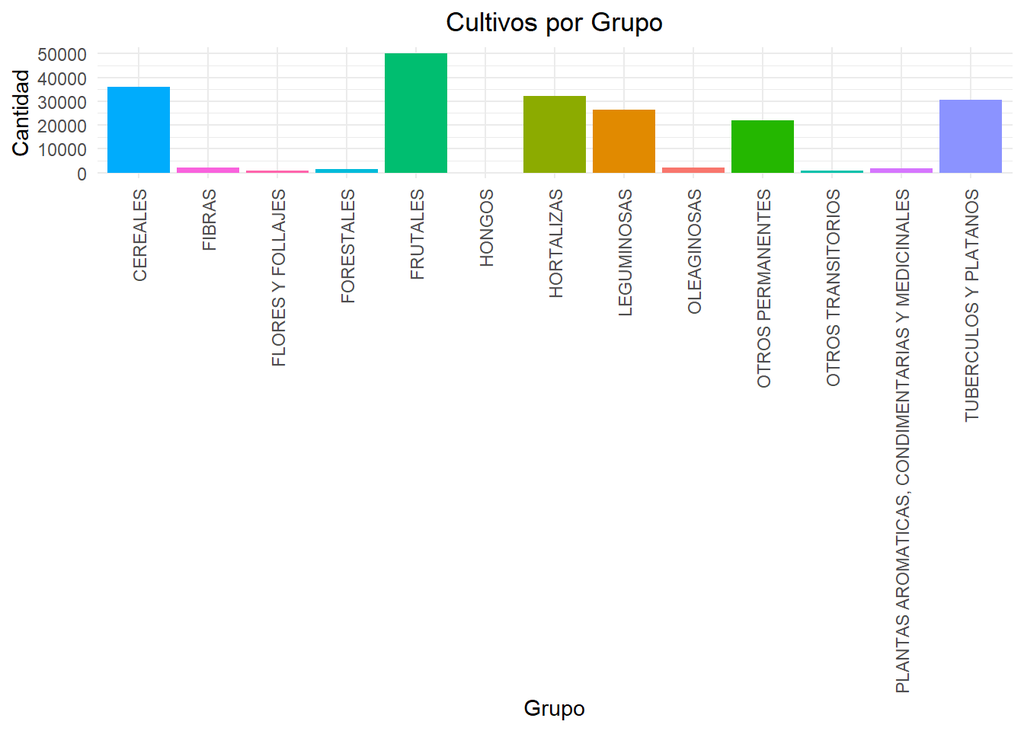

### Variable SUBGRUPO.DE.CULTIVO

Se refiere a una categorización aún más específica de plantas dentro de un grupo de cultivo más amplio. Mientras que un grupo de cultivo agrupa plantas con características generales similares, como requerimientos de crecimiento o tipo de cultivo, un subgrupo de cultivo se utiliza para clasificar plantas dentro de ese grupo en función de características aún más específicas.

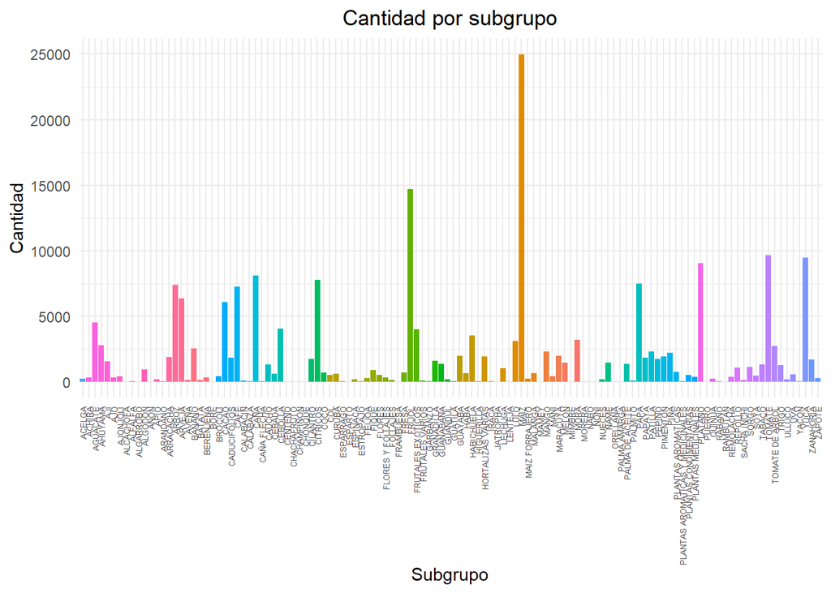

### Variable CULTIVO

Se refiere al cultivo del cual se obtuvieron los datos.

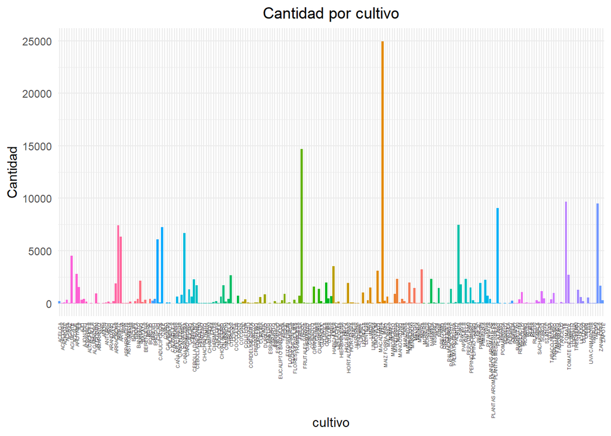

### Variable ESTADO.FISICO.DE.CULTIVO

Se refiere al tipo de producto que se obtiene del cultivo.

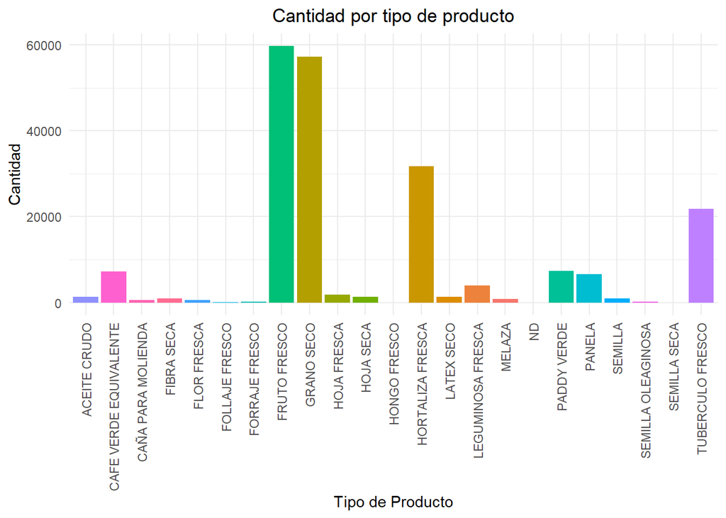

### Variable CICLO.DE.CULTIVO

Se refiere al ciclo de cultivo;transitorio, anual o permanente,

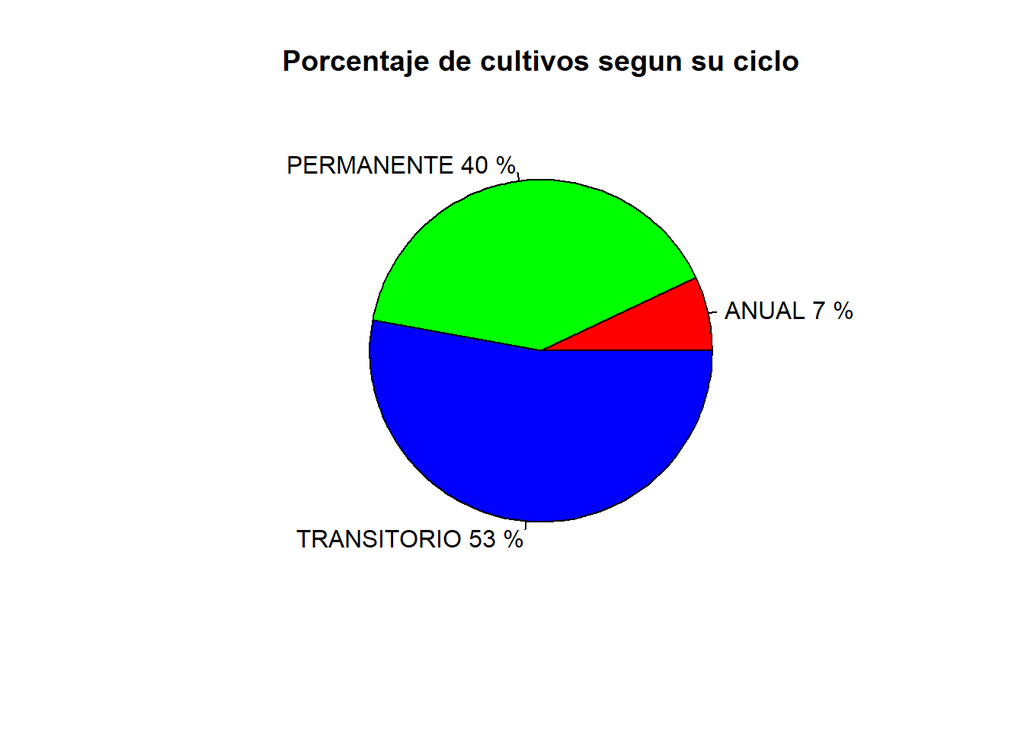

### Variable PERIODO

Se refiere al año y/o semestre donde se tomaron los datos dependiendo del cultivo, el semestre puede ser A(Primer semestre) o B(segundo semestre).

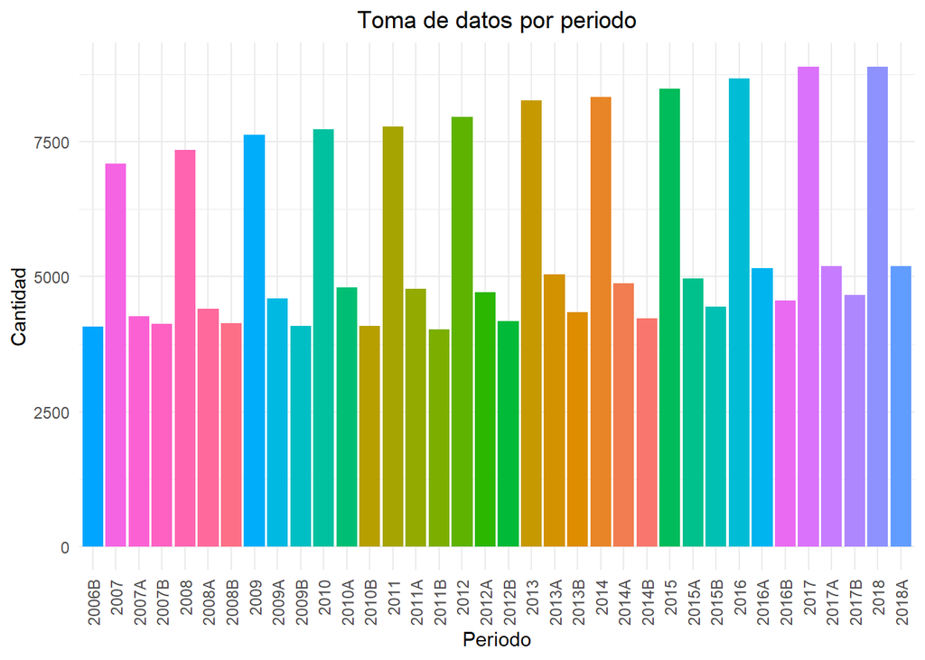

### Variable Area.Sembrada

Se refiere al area sembrada dada en hectareas (ha);para tener en cuenta; 1 hectarea = 10000 m^2.

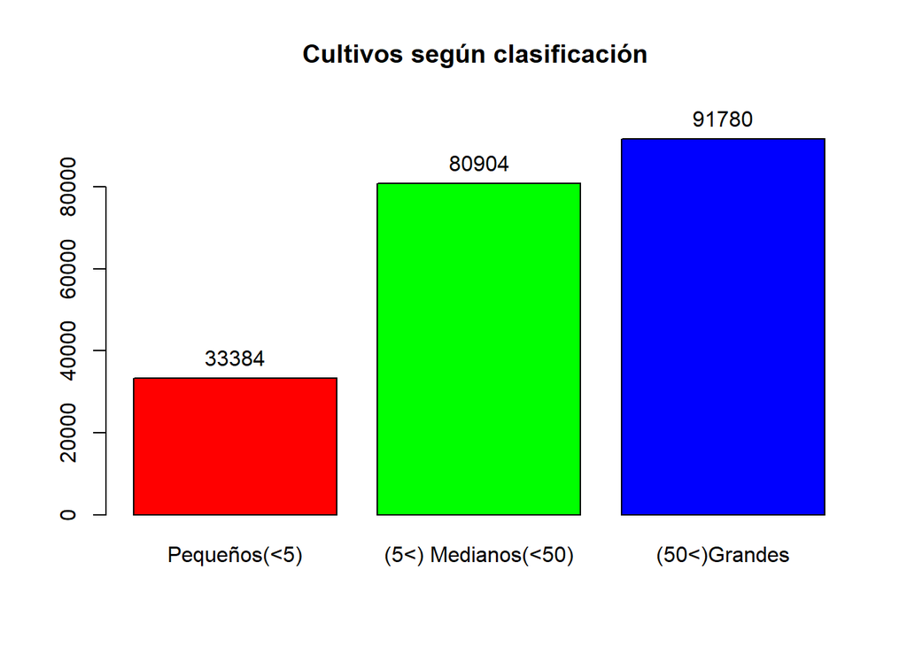

### Variable Area.Cosechada

Se refiere al area dada en hectareas (ha) en la cual se obtuvo producto al momento de cosechar;para tener en cuenta; 1 hectarea = 10000 m^2.

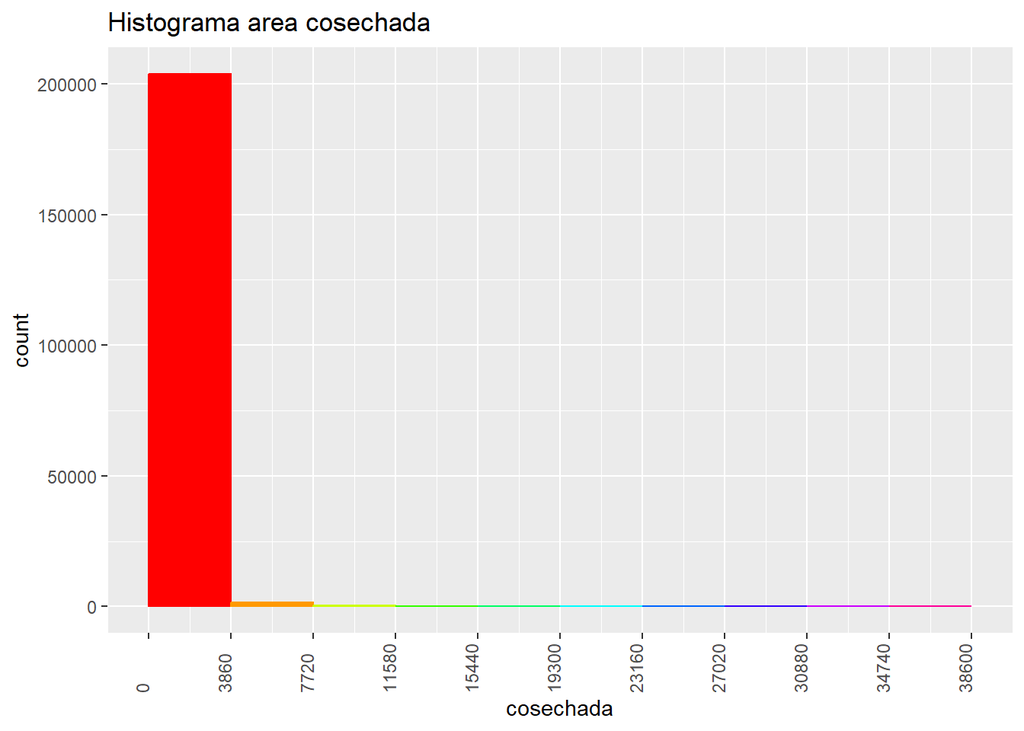

### Produccion

Se refiere a la cantidad de producto obtenida, esta variable esta dada en toneladas (t).

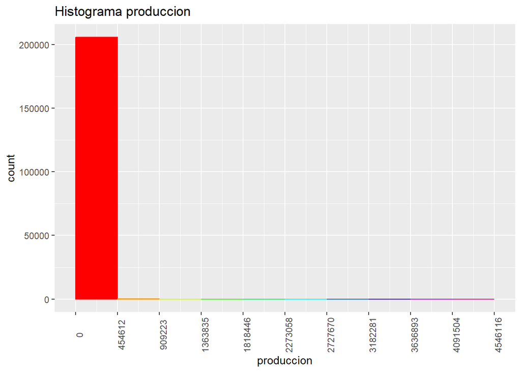

### Rendimiento

Se refiere a la cantidad de producto obtenida por area sembrada, esta dada en toneladas por hectare (t/ha).

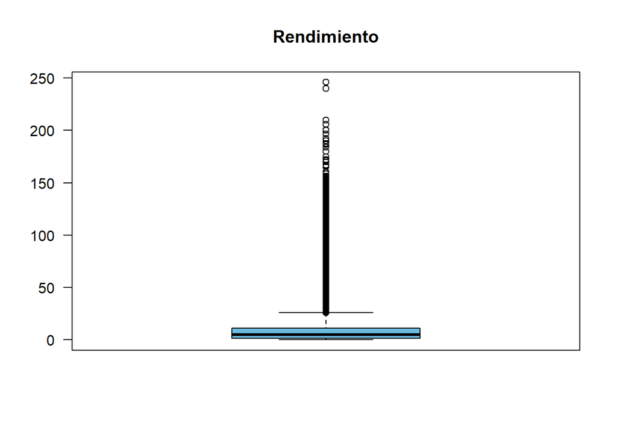